# Retention Index Data Description

Degnan, David J. & Bramer, Lisa M.

Last updated: 09/23/2022

# 1 General Data Descriptions

## 1.1 Terms

**Sample:** Identification results from a mass spectra file from with a standard sample (known compounds) or complex sample (not all compounds known - fungi, urine, etc.).

**Dataset:** Collection of samples with run with one FAMEs dataset, which is used by CoreMS to calculate retention indices to assign metabolites to spectra

**Metabolite:** An identified compound formed in or necessary for metabolism. We generally refer to our dataset as “small molecules”.

## 1.2 Datasets

The current data used for all below retention index analyses was comprised on 12.30.21 and contains 548 datasets with 13487 true positive annotations.

## 1.3 Sample Types

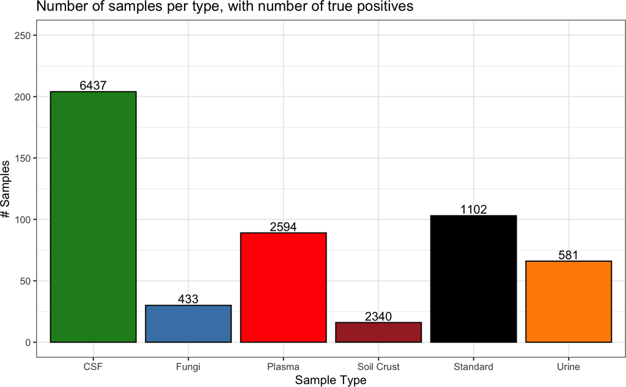

**Figure 1: The count of samples per sample type included in this study, with the number of metabolites across all of those samples above.**

```
## # A tibble: 6 × 2
##   `Sample Type` `True Positive Rate`
##   <chr>                        <dbl>
## 1 Fungi                        36.7
## 2 Soil Crust                   36.3
## 3 Urine                        35.5
## 4 CSF                          31.6
## 5 Plasma                       29.1
## 6 Standard                      4.20
```

## 1.4 Metabolites

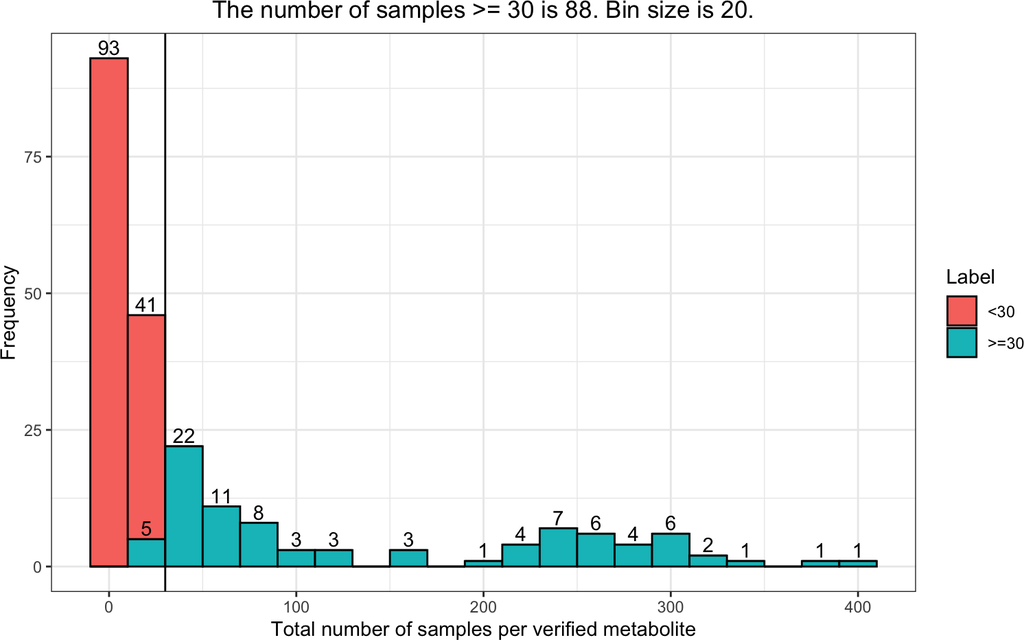

**Figure 2: The frequency of each metabolite’s number of samples in bins of 20. For example, a sample with n = 9 would be counted in the first bin, and a sample with n = 32 would be counted in the second bin. Red bars are the counts of identified metabolites with less than 30 samples, and blue is the count of metabolites with more than or equal to 30 samples.**

A majority of metabolites (134 of 222) have less than 30 samples. Of the remaining metabolites, 88 have >= 30, 40 have >= 100, and 23 have >= 250 (**Fig. 2**).

# 2 Retention Index Difference Trends

## 2.1 General

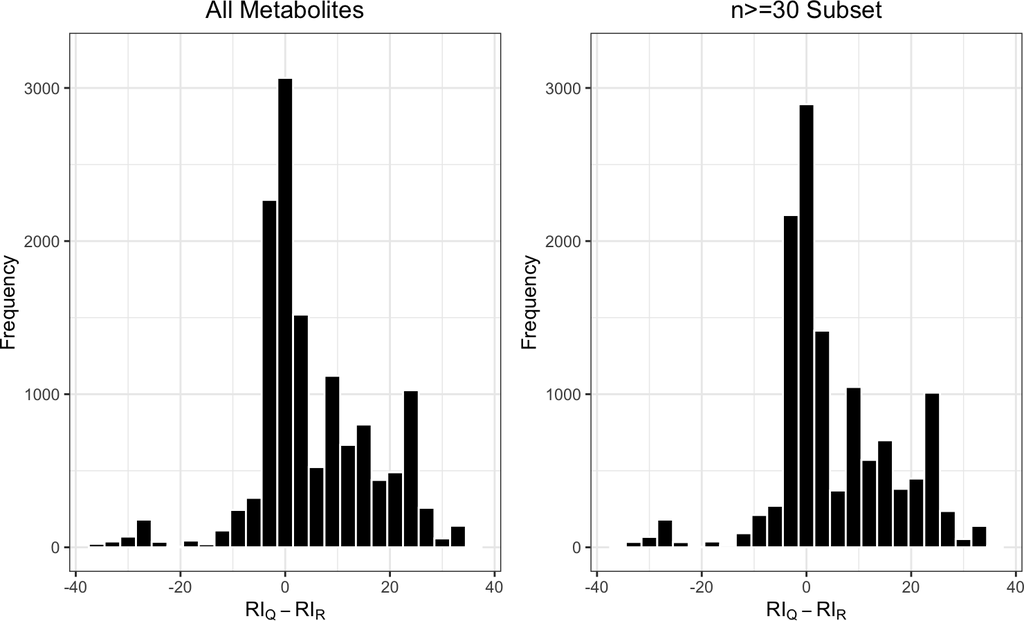

**Figure 3: The retention index distribution across all verified metabolites (left) and across the subset of samples with at least 30 identifications (right).**

A majority of metabolites fall within a retention difference of -30 and 30. The shapes of the distributions for the full data and the N>=30 subset are similar (**Fig. 3**).  
This means we are confident that are N>=30 subset reflects the overall dataset and feel comfortable moving forward with this data.

**NOTE:** All results beyond this point are for metabolites with an N >= 30 *ONLY.*

## 2.2 Per Metabolite

**Trelliscope 1: The retention index difference distribution per metabolite.**

## 2.4 Per Sample Metadata

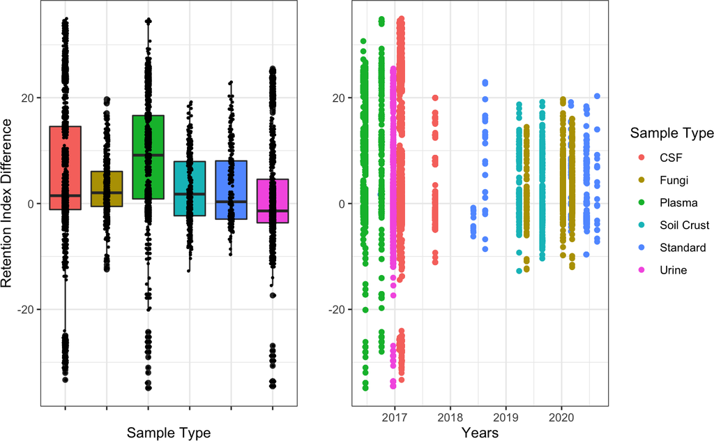

**Figure 4: Retention index difference distributions per sample type (left) and in years since 2000 (right).**

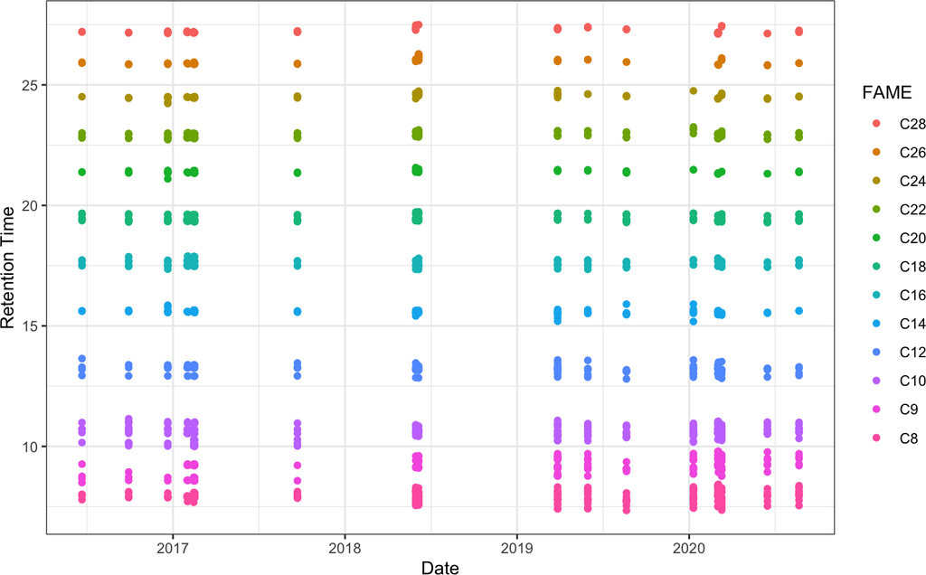

**Figure 5: FAMES retention time versus date the sample was collected.**

There is no convincing evidence that retention times for FAMES standards drift with time (**Fig. 5**). Variations in retention time may be better explained by sample type (**Fig. 4**) or that there is natural variation each time samples are collected.

## 2.5 Per Theoretical RI

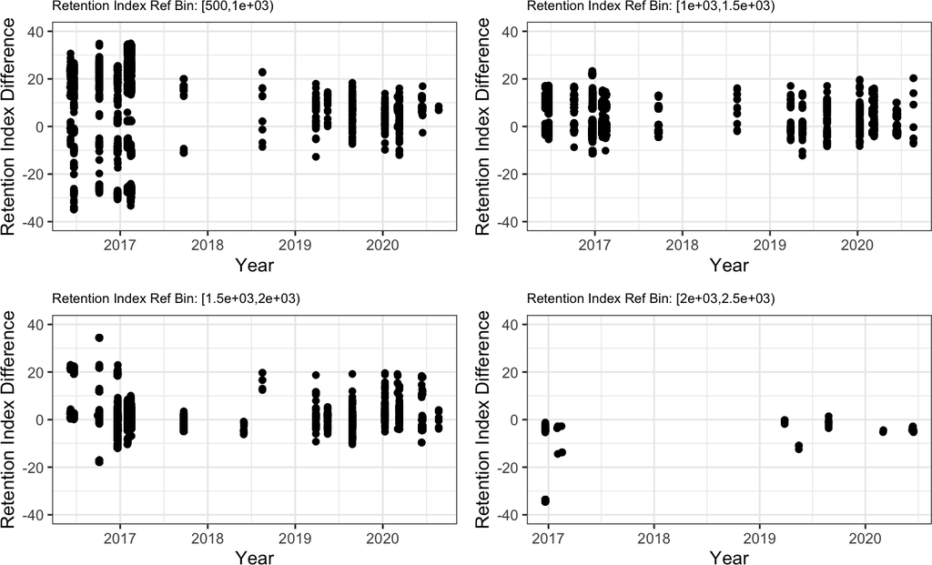

**Figure 6: Retention index difference per retention index reference bin (top left: 500 to 1000, top right: 1000 to 1500, bottom left 1500 to 2000, and bottom right 2000 to 2500), split by year.**

To investigate whether reference retention index has a relationship with retention index difference, we split the data into chunks of 500 reference retention index. There is no obvious relationship though it is worth noting that at lower reference retention indices, the likelihood that the metabolite’s retention index will be overestimated is higher (**Figure 6**). Likewise, at higher reference retention indices, the likelihood that the true value will be underestimated is higher.

## 2.6 Per Abundance

**Trelliscope 2: The relationship between a metabolite’s abundance and retention index difference.**

# 3 Retention Index Difference Summary Stats

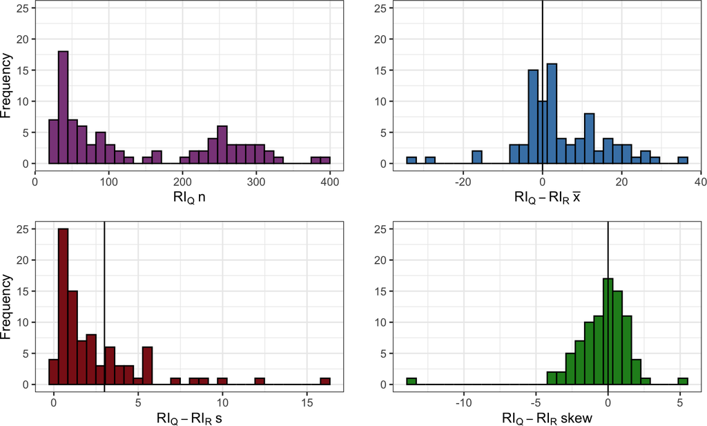

The retention index distribution values for our dataset do not closely match the assumptions of the retention index score (**Figure 7**), where $\mu$ = 0, $\sigma$ = 3, and skew = 0. Next, we will see how closely our data follows these assumptions, and the effects of violating these assumptions.

# 4 Publication Figure

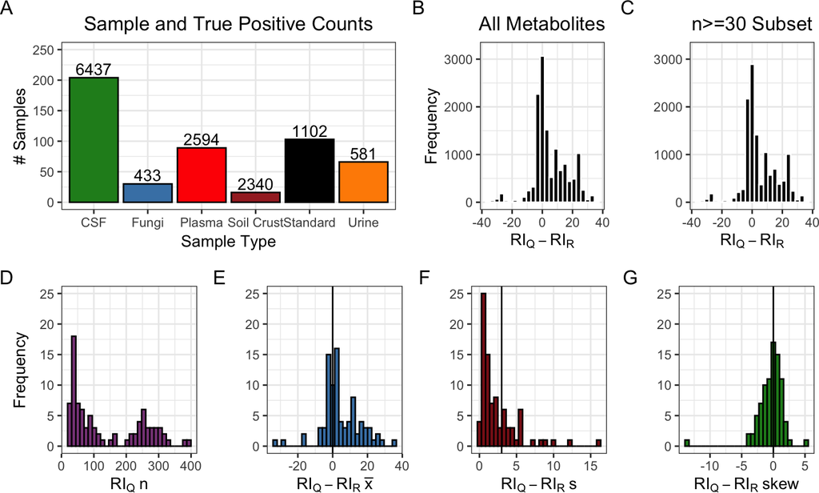

# 5 Poster Figures

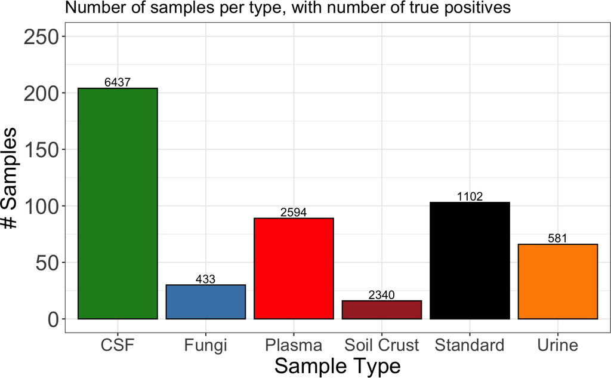

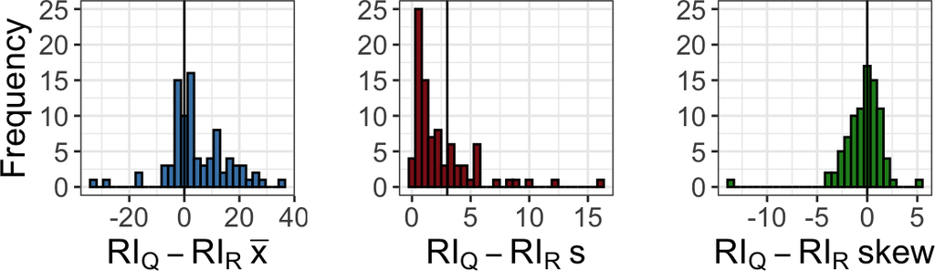